# Coursework Report

*N* removed NAs: 6

*N* removed <18: 27

**Correct typo age:** 21

*N* total clean: 135

| Group | *N* | *M*<sub>age</sub> | % green |
| --- | --- | --- | --- |
| Control | 68 | 20.85 | 54.9 |
| Experim | 67 | 20.64 | 40.8 |

| Gender | *N* | *M*<sub>age</sub> | % green |
| --- | --- | --- | --- |
| Male | 70 | 20.46 | 45.71 |
| Female | 42 | 20.98 | 44.44 |
| Other | 23 | 21.22 | 60.87 |

**Main analysis results**

**car:**  
χ<sup>2</sup>(1) = 2.16, *p* = .142

**cleaner:**  
χ<sup>2</sup>(1) = 1.25, *p* = .264

**dishwasher:**  
χ<sup>2</sup>(1) = 3.34, *p* = .068

[interactive chart not shown]

[figure not shown]

[interactive chart not shown]

# Coursework Report

Analysing Data, Spring 2020

# Methods

## Participants

Table 1 *Descriptive statistics by condition*

[output not shown]

Table 2 *Descriptive statistics by gender*

[output not shown]

## Design

This study is questioning if a consumer’s product choice (luxury or ‘green’) will be influenced by activating status motives or not. The independant variable is whether the status motives are activated or not. This is done by giving the particiant a story to read, which either tells a story of a man graduating university, getting a job and receiving a promotion (activating status response), or a control, where someone loses a ticket to a concert and finds it again (not eliciting the status response). The dependant variable is the product choice (‘green’ or luxury), this will be measured using an online questionnaire, first giving a description of the products (car, cleaner or dishwasher), then asking whether the participant would choose the luxury version or the ‘green’ version of each product. This study predicts that by activating status motivates (through reading either a status story or a control story), the participants will choose the ‘green’ versions of a car, cleaning fluid and dishwasher over the luxury versions of the same products.

# Results

The graphs also show that the control condition chose the ‘green’ product choice more often than the experimental condition. Graph 1 shows that 54.41% of control participants chose the ‘green’ car, compared to 40.3% of the experimental condition. Graph 2 shows that 56.72% of controls chose the ‘green’ cleaning product, whereas, 46.27% of experimental condition participants did the same. Finally, graph 3 shows that 52.94% of control participants chose the ‘green’ dishwasher compared to 35.82% of experimental condition participants. This might mean that high status motives doesn’t cause people to behave more ‘green’. This is debated further in the discussion.

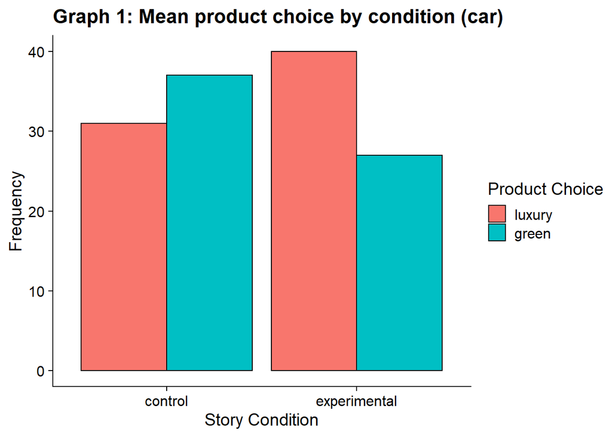

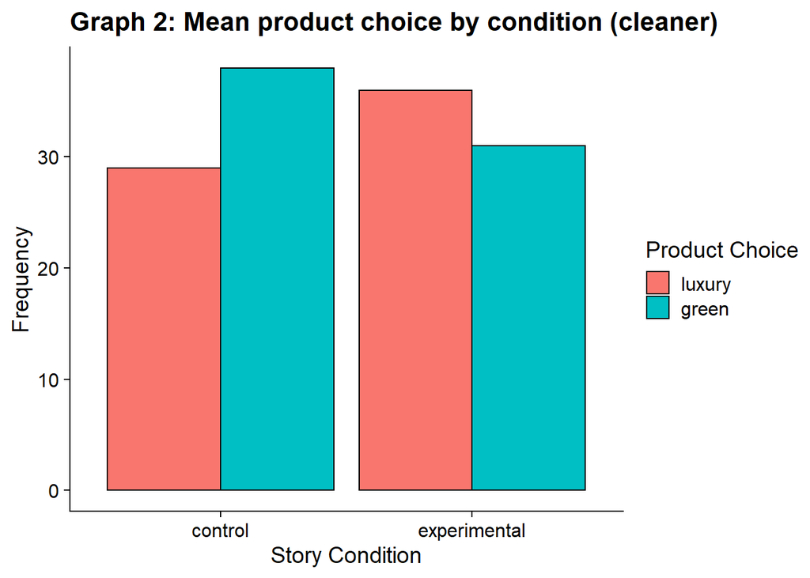

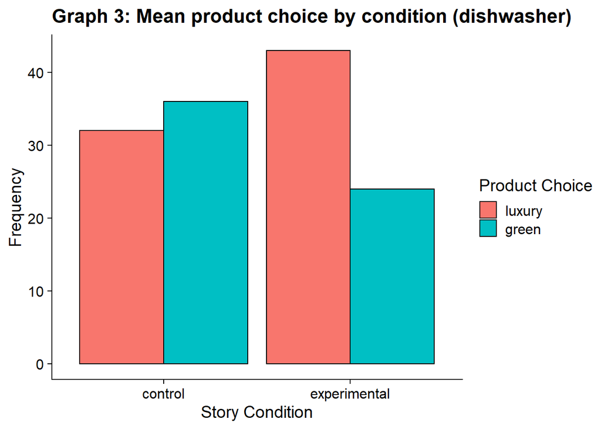

# Discussion

The current study was a replication of Griskevicius, Tybur and Van den Bergh (2010), who found in their study, that activating status motives among participants, resulted in them choosing the ‘green’ product when given the option of choosing environmentally friendly, or luxury versions of a car, cleaner and dishwasher. Controversial to Griskevicius et al. (2010)’s findings, the results from the current study did not support the proposed hypothesis, finding that the control condition group chose the ‘green’ product more often than the experimental condition group. Although these results seem unimportant, they might not mean that there is no relationship between the variables, but rather that activating status motives, may make people choose luxury items rather than environmentally friendly items. To support this, Nelissen and Meijers (2011) suggest that according to costly signalling theory, buying luxury products is a beneficial social strategy and projects status to others.

The results to the current study may alternatively mean that high status motives, do in fact encourage individuals to buy ‘green’ items, but only when they are in the public eye. The participants in the current study were answering a questionnaire online, and therefore were not being seen make the decisions. A study by Van der Wal, van Horen and Grinstein (2016) supports this idea, finding that in a real life situation, despite stating that they were eco-friendly beforehand, the high status group were more likely to buy bags while grocery shopping at a sustainable store, while the low status condition brought their own bags; suggesting that the high status group only behave this way for social status, whereas the low status group are doing it for environment benefits. This highlights the limitation in the current research as well as the original study of low ecological validity, because they both took place in a lab, thus meaning that we are unable to generalise the results to real life situations, as well as other cultures (as the present study was conducted on a western culture).

The underlying message of this research is that by activating status motives, it is possible to encourage prosocial behaviour (in the form of environmentally friendly purchases). Kafashan, Sparks, Griskevicius and Barclay (2010) explain how there is a bi-directional relationship between social status and prosocial behaviour, while suggesting that if we can understand this relationship better, there may be a method of manipulating it to motivate individuals to become more prosocial, by drawing on a human’s fundamental need for social status (Anderson, Hildreth & Howland, 2015). There needs to be more research into the bi-directional relationship and what affects it, to be able to control prosocial behaviour. In order to do this, we need to find out what drives environmentally friendly behaviour, in terms of cognitive processes and environmental variables that contribute to it. This would be advantageous in finding methods to help individuals to act in a more environmentally conscious and prosocial manner. Additionally, it would be interesting to find out if this eco behaviour is carried out in other settings, such as recycling at home, or actually choosing between buying a ‘green’ or luxury car.

Although the results of the current study were not significant, there are many other interesting pathways and questions that this area of research highlights. For example, activating social status might encourage individuals to buy luxury items rather than eco ones, or the idea that pro-environmental behaviour, by activating status, may only occur when the individual is in the public eye. There is a significant amount of research still to be done in this field, which also raises many questions (outlined in the previous paragraph). As a final thought, when looking to encourage productive behaviour, whether one views it as prosocial or pro-environmental behaviour that is driven by social status, both are necessary for the survival of our species and planet.

# References

Anderson, C., Hildreth, J. A. D. & Howland, L. (2015). Is the desire for status a fundamental human motive? A review of the empirical literature. *Psychological Bulletin, 141*(3), 574.

Griskevicius, V., Tybur, J, M. & Van den Bergh, B. (2010). Going Green to be Seen: Status, Reputation and Conspicuous Conservation. *Journal of Personality and Social Psychology, 98*(3), 392-404.

Kafashan, S., Sparks, A., Griskevicius, V., & Barclay, P. (2014). Prosocial behavior and social status. *The psychology of social status* (pp. 139-158). Springer: New York, NY.

Nelissen, R. M. A. & Meijers, M, H, C. (2011). Social benefits of luxury brands as costly signals of wealth and status. *Evolution of Human Behaviour, 32*(5), 343-355.

Van der Wal, A. J., van Horen, F. & Grinstein, A. (2016) The Paradox of ‘green to be seen’: Green high-status shoppers excessively use (branded) shopping bags. *International Journal of Research in Marketing, 33*(1), 216-219.